# 美国网贷平台Prosper的用户分析

leechpee

2018年6月22日

本文用R语言对网贷平台Prosper进行数据分析，简单总结出网贷平台用户画像情况。

## 2、数据分析探索

```r
Sys.setlocale('LC_ALL','C')
```

```
## [1] "C"
```

```r
# 加载所需包

library(GGally)
library(scales)
library(memisc)
library(gridExtra)
library(tidyr)
library(mice)
library(dplyr)
```

```r
library(stringr)
library(ggplot2)
library(lattice)
library(MASS)
library(Rcpp)# 使用c++语言
library(randomForest) # 分类算法
library(Amelia)# 有缺失值绘图的函数
library(splines) # 数据差值包
library(ggthemes) # 可视化
```

```r
# 导入数据并预览数据
loandata <- read.csv('data/prosperLoanData.csv', stringsAsFactors = FALSE, na.strings = c(""))
str(loandata)
```

```
## 'data.frame':    113937 obs. of  81 variables:
##  $ ListingKey                         : chr  "1021339766868145413AB3B" "10273602499503308B223C1" "0EE9337825851032864889A" "0EF5356002482715299901A" ...
##  $ ListingNumber                      : int  193129 1209647 81716 658116 909464 1074836 750899 768193 1023355 1023355 ...
##  $ ListingCreationDate                : chr  "2007-08-26 19:09:29.263000000" "2014-02-27 08:28:07.900000000" "2007-01-05 15:00:47.090000000" "2012-10-22 11:02:35.010000000" ...
##  $ CreditGrade                        : chr  "C" NA "HR" NA ...
##  $ Term                               : int  36 36 36 36 36 60 36 36 36 36 ...
##  $ LoanStatus                         : chr  "Completed" "Current" "Completed" "Current" ...
##  $ ClosedDate                         : chr  "2009-08-14 00:00:00" NA "2009-12-17 00:00:00" NA ...
##  $ BorrowerAPR                        : num  0.165 0.12 0.283 0.125 0.246 ...
##  $ BorrowerRate                       : num  0.158 0.092 0.275 0.0974 0.2085 ...
##  $ LenderYield                        : num  0.138 0.082 0.24 0.0874 0.1985 ...
##  $ EstimatedEffectiveYield            : num  NA 0.0796 NA 0.0849 0.1832 ...
##  $ EstimatedLoss                      : num  NA 0.0249 NA 0.0249 0.0925 ...
##  $ EstimatedReturn                    : num  NA 0.0547 NA 0.06 0.0907 ...
##  $ ProsperRating..numeric.            : int  NA 6 NA 6 3 5 2 4 7 7 ...
```

[output cut: 67 more lines]

从上可见，数据集包含81个变量，113,937条数据，由于数据变量太多，本文只对重要变量作解释说明，若需详细了解变量含义，请点击[变量词典](https://docs.google.com/spreadsheets/d/1gDyi_L4UvIrLTEC6Wri5nbaMmkGmLQBk-Yx3z0XDEtI/edit#gid=0)。

| 变量名称 | 变量含义 |
| --- | --- |
| ListingCreationDate | 表创建时间(可能是交易开始计息时间) |
| LoanStatus：贷款状态(Completed、Current、Defaulted、Chargedoff等) |  |
| EmploymentStatus | 受雇佣状态(Self-employed、Employed等) |
| EmploymentStatusDuration | 受雇佣状态持续时间(以月为计算单位) |
| IsBorrowerHomeowner | 借款人是否拥有房屋 |
| CreditScoreRangeLower/CreditScoreRangeUpper | 消费信用最低/最高分 |
| InquiriesLast6Months | 最近6个月查过多少次征信记录 |
| BorrowerRate | 借款标利率 |
| Term | 期限，筹资者通过网贷平台进行借款时所承诺的最终偿还期限 |
| CreditGrade/ProsperRating(Alpha) | 信用等级，前者反映的是2009年7月1日前客户的信用等级，后者反映的是2009年7月1日后的信用等级 |
| CreditScore | 由消费信用公司提供的消费信用评分，类似于国内的芝麻信用分 |
| StatedMonthlyIncome | 客户月收入，月收入越高，投资者对该借款本息按时回流越有信心 |
| DelinquenciesLast7Years | 信用资料提交时借款人过去7年违约次数，该指标在一定程度上可以体现借款标的发布者的信用状况 |
| BankCarduse | 信用资料提交时借款人信用卡使用额度和信用卡总透支额度的百分比 |
| LoanOriginalAmount | 借款人在借款时已经向prosper借入的资金，如果没有历史记录则为0 |
| DebtToIncomeRatio | 借款人的债务收入比 |
| Occupation | 贷款人职业 |
| IncomeRange | 贷款人年收入范围 |
| BorrowerState | 贷款人所在州 |
| Customer_clarify | 0或NA是未在prosper贷过款的客户，反之是贷过款的 |

```r
# 数据处理

# 日期字符转换
loandata$LoanOriginationDate <- as.Date(loandata$LoanOriginationDate)
loandata$ListingCreationDate <- as.Date(loandata$ListingCreationDate)

#复制数据
loandata_copy <- loandata

# 选择子集
loandata <- select(loandata, LoanStatus, CreditGrade,
                   ProsperRating..Alpha., BorrowerState,
                   IncomeRange, Occupation, DebtToIncomeRatio,
                   DelinquenciesLast7Years, Term, BorrowerRate,
                   IsBorrowerHomeowner, ListingCategory..numeric.,
                   EmploymentStatus, EmploymentStatusDuration, InquiriesLast6Months,
                   LoanOriginationDate, StatedMonthlyIncome, LoanOriginalAmount)

# 对客户的消费信用评级,数据中有最高和最低两个值,
# 将这两个数值取平均值作为客户的消费信用评分
loandata$CreditScore <- (loandata_copy$CreditScoreRangeUpper +
                           loandata_copy$CreditScoreRangeLower)/2


# 平台信用评级排序
# 平台信用评级2009年7月1日之前用CreditGrade
loandata$CreditGrade <- ordered(loandata_copy$CreditGrade,
                                levels = c("NC", "HR", "E", "D", "C", "B", "A", "AA"))
# 平台信用评级2009年7月1日之后用ProsperRating..Alpha.
loandata$ProsperRating..Alpha. <- ordered(loandata_copy$ProsperRating..Alpha.,
                                          levels = c("NC", "HR", "E", "D", "C", "B", "A", "AA"))

# 2009年7月1日是prosper业务的一个分界点，所以以此日期将数据划分为两个时段
loandata$Phase[loandata_copy$ListingCreationDate > "2009-07-01"] <- "After 2009"
loandata$Phase[loandata_copy$ListingCreationDate < "2009-07-01"] <- "Before 2009"

# 对未在prosper贷过款的客户建立库(数据解释:0或NA是未在prosper贷过款的客户，反之是贷过款的)
loandata$Customer_clarify[loandata_copy$TotalProsperLoans > 0] <- "Previous Borrower"
loandata$Customer_clarify[loandata_copy$TotalProsperLoans == 0] <- "New Borrower"
loandata$Customer_clarify[is.na(loandata_copy$TotalProsperLoans)] <- "New Borrower"
loandata$Customer_clarify <- factor(loandata$Customer_clarify)

# 对信用卡使用情况进行离散化
loandata$BankCardUse[loandata_copy$BankcardUtilization
                     < quantile(loandata_copy$BankcardUtilization,
                                probs = 0.25, "na.rm" = TRUE)] <- "Mild Use"

loandata$BankCardUse[(loandata_copy$BankcardUtilization >=
                        quantile(loandata_copy$BankcardUtilization, probs = 0.25, na.rm = TRUE)) & (
                          loandata_copy$BankcardUtilization <
                            quantile(loandata_copy$BankcardUtilization, probs = 0.5, na.rm = TRUE))] <- "Medium Use"

loandata$BankCardUse[(loandata_copy$BankcardUtilization >=
                        quantile(loandata_copy$BankcardUtilization, probs = 0.5, na.rm = TRUE)) & (
                          loandata_copy$BankcardUtilization < 1)] <- "Heavy Use"

loandata$BankCardUse[loandata_copy$BankcardUtilization >= 1] <- "Super Use"

# factor(loandata$BankCardUse, levels = c("Mild Use", "Medium Use", "Heavy Use", "Super Use"))
```

```r
# 将LoanStatus中的Past Due多少天统一合并成pastDue组
#类型转换
loandata$LoanStatus <- as.character(loandata$LoanStatus)
str(loandata$LoanStatus)
```

```
##  chr [1:113937] "Completed" "Current" "Completed" "Current" "Current" ...
```

```r
pastDue <- c("Past Due (1-15 days)","Past Due (16-30 days)",
             "Past Due (31-60 days)","Past Due (61-90 days)",
             "Past Due (91-120 days)","Past Due (>120 days)")
loandata$LoanStatus[loandata$LoanStatus %in% pastDue] <- "pastDue"

# 将LoanStatus中的Current、 Cancelled合并成Current组
loandata$LoanStatus[loandata$LoanStatus == "Cancelled"] <- "Current"
# 将LoanStatus中的Chargedoff、Defaulted合并成Chargedoff组
loandata$LoanStatus[loandata$LoanStatus == "Defaulted"] <- "Chargedoff"
#将LoanStatus中的Completed、FinalPaymentInProgress合并成Completed组
loandata$LoanStatus[loandata$LoanStatus == "FinalPaymentInProgress"] <- "Completed"
#将LoanStatus中的Completed、pastDue合并成Completed组
loandata$LoanStatus[loandata$LoanStatus == "pastDue"] <- "Completed"
#将LoanStatus中的Current组去掉
loandata <- loandata[!(loandata$LoanStatus == "Current"), ]

table(loandata$LoanStatus)
```

```
##
## Chargedoff  Completed
##      17010      40346
```

```r
# 把新的loandata赋值给loandata_copy
loandata_copy <- loandata

# LoanStatus中完成的状态置为1，坏账置为0
loandata$LoanStatus[loandata_copy$LoanStatus == "Chargedoff"] <- 0
loandata$LoanStatus[loandata_copy$LoanStatus == "Completed"] <- 1

table(loandata$LoanStatus)
```

```
##
##     0     1
## 17010 40346
```

```r
# 数据探索
#主题载入
mythem <- theme(
  legend.position = "bottom",
  axis.text.x = element_text(angle = 90),
  plot.title = element_text(
    colour = "black",
    face = "bold",
    vjust = 1,
    hjust = .5
  ))

#ggplot2主题设置
mythem1 <- theme(
  legend.position = "bottom",
   plot.title = element_text(
    colour = "black",
    face = "bold",
    vjust = 1,
    hjust = .5
  )
)
```

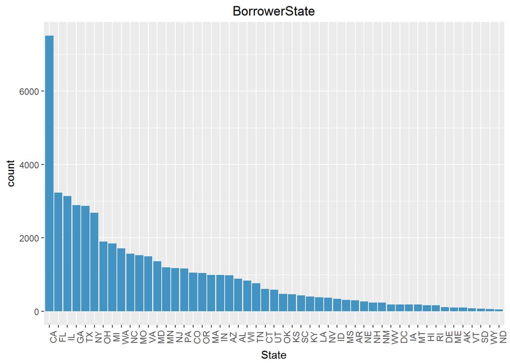

```r
# 借款人地址的分布
amount <- data.frame(table(loandata$BorrowerState))

ggplot(data = amount, mapping = aes(x = reorder(Var1, -Freq),y = Freq))+
    # 生成标题
    ggtitle('BorrowerState') +
    # 生成条形图，每个柱的宽度0.8，填充'#FF9999'的颜色
    geom_bar(stat = 'identity', fill = "#4393C3") +
    # 标题居中
    theme(plot.title = element_text(hjust = 0.5), axis.text.x = element_text(angle = 90)) +
    # 在条形图上标注数字
    # geom_text(aes(label = Freq),position = position_stack(vjust = 1.05)) +
    # 横轴标签'各区'
    xlab('State') +
    # 纵轴标签'数量'
    ylab('count')
```

```r
# 借款人收入分布
loandata$IncomeRange <- ordered(loandata_copy$IncomeRange,
                                levels = c("Not displayed", "Not employed",
                                           "$0", "$1-24,999", "$25,000-49,999",
                                           "$50,000-74,999", "$75,000-99,999",
                                           "$100,000+"))
table(loandata$IncomeRange)
```

```
##
##  Not displayed   Not employed             $0      $1-24,999 $25,000-49,999
##           7737            558            610           4738          17080
## $50,000-74,999 $75,000-99,999      $100,000+
##          13435           6777           6421
```

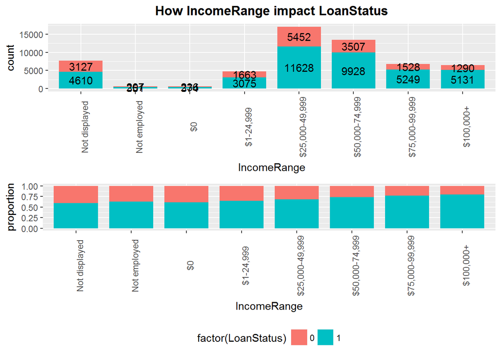

```r
gir <- ggplot(loandata, mapping = aes(
  x = IncomeRange,
  y = ..count..,
  fill = factor(LoanStatus)
)) + mythem
gir1 <- gir + geom_bar(stat = "count",
                       position = "stack",
                       width = 0.8) +
  labs(title = "How IncomeRange impact LoanStatus") +
  geom_text(stat = "count",
            aes(label = ..count..),
            position = position_stack(vjust = 0.5))+
  theme(legend.position = "none")

gir2 <- gir + geom_bar(stat = "count",
                       position = "fill",
                       width = 0.8) + labs(y = "proportion")

grid.arrange(gir1, gir2, nrow = 2)
```

从上图可见，收入在$25000-$75000区间网络借钱人数占主要，且随着年收入的增加，违约比例在逐渐下降。

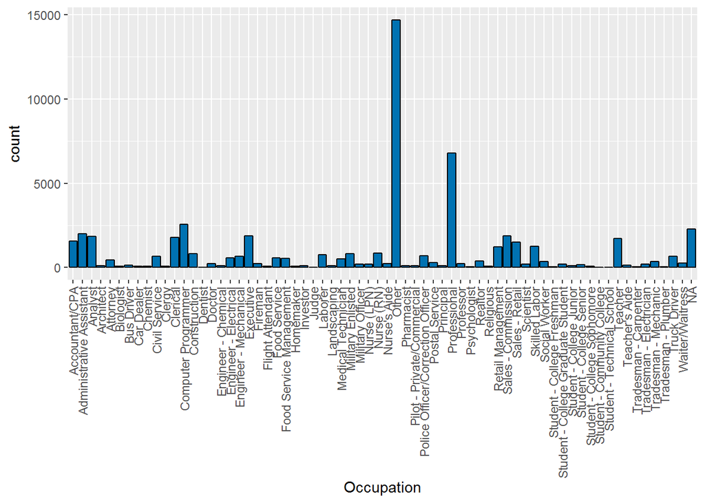

```r
# 借款人的职业
qplot(data=loandata, x=Occupation, color=I('black'),fill=I("#0072B2")) +
  theme(axis.text.x = element_text(angle = 90, vjust = 0.5, hjust=1))
```

在职业选项上，很多借款人似乎不太愿意透露自己的信息，都选择填了other这个选项。因此这项数据的真实性让人怀疑。

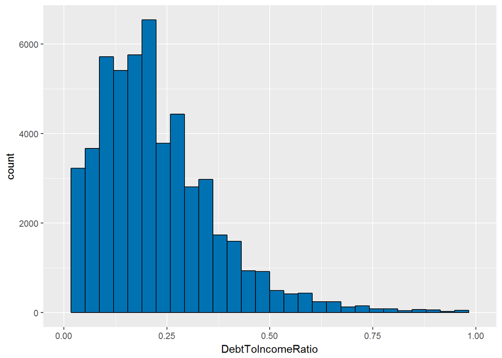

```r
# 借款人债务收入比
ggplot(data = loandata, aes(DebtToIncomeRatio)) +
  geom_histogram(color=I('black'), fill=I("#0072B2")) + xlim(0, 1)
```

从上图可以看到，债务收入比呈现右偏的形态，说明大部分借款人的债务收入比较低,集中在0-0.25之间，这说明该平台的借款人的资金状况良好，对偿还债务能力比较强。

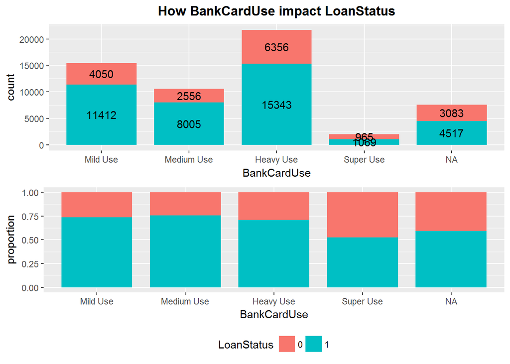

```r
# 借款人信用卡使用程度分布
loandata$BankCardUse <- factor(loandata$BankCardUse,
         levels = c("Mild Use", "Medium Use", "Heavy Use", "Super Use"))
gbcu <- ggplot(loandata, mapping = aes(
       x = BankCardUse,
       y = ..count..,
       fill = LoanStatus)) + mythem1

gbcu1 <- gbcu + geom_bar(stat = "count",
                         position = "stack",
                         width = 0.8) +
                         labs(title = "How BankCardUse impact LoanStatus") +
                         geom_text(stat = "count",
                         aes(label = ..count..),
                         position = position_stack(vjust = 0.5)) +
                         theme(legend.position = "none")

gbcu2 <- gbcu + geom_bar(stat = "count",
                         position = "fill",
                         width = 0.8) + labs(y = "proportion")

grid.arrange(gbcu1, gbcu2, nrow = 2)
```

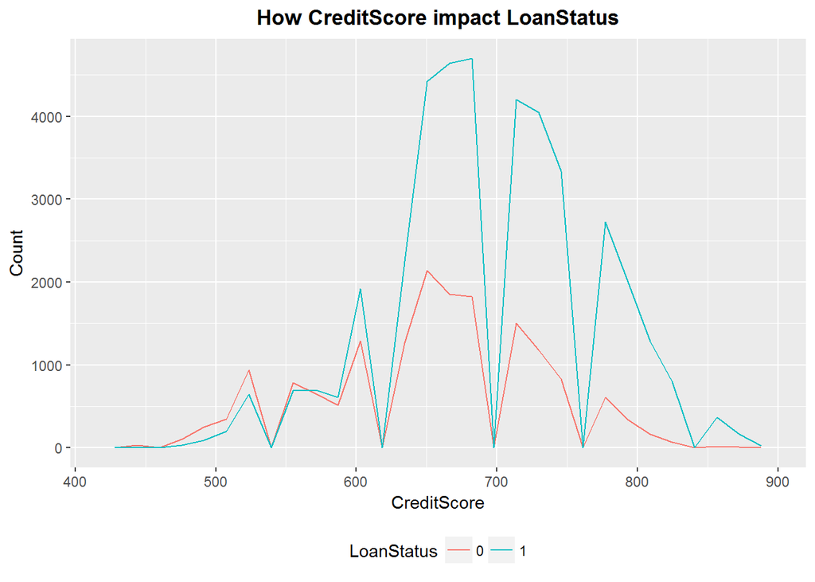

```r
# 客户信用等级分布
# CreditScore对LoanStatus的影响
ggplot(data = loandata[(!is.na(loandata$CreditScore)) &
                         loandata$CreditScore > 400,],
       aes(x = CreditScore, color = LoanStatus)) +
  geom_line(aes(label = ..count..), stat = 'bin')  +
  labs(title = "How CreditScore impact LoanStatus",
       x = "CreditScore",
       y = "Count",
       fill = "LoanStatus") +
  theme(
    legend.position = "bottom",
    plot.title = element_text(
      colour = "black",
      face = "bold",
      vjust = 1,
      hjust = .5
    )
  )
```

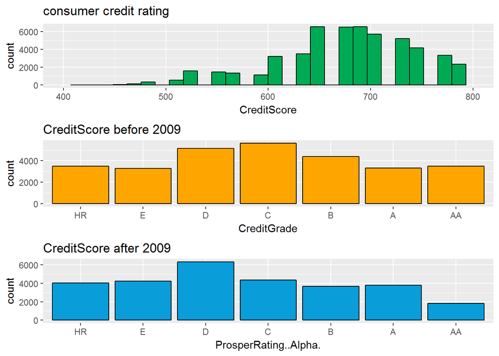

```r
q1 <- qplot(CreditScore,data = loandata,color=I('black'),fill=I('#00AA55')) +
  xlim(400,800) +
  ggtitle('consumer credit rating')
q2 <- qplot(CreditGrade,data = subset(loandata,LoanOriginationDate < "2009-07-01"),color=I('black'),fill=I('orange')) +
  scale_x_discrete(limits = c("HR","E","D","C","B","A","AA")) +
  ggtitle('CreditScore before 2009')
q3 <- qplot(x = ProsperRating..Alpha.,data = subset(loandata,
  LoanOriginationDate > "2009-07-01"), color=I('black'),fill=I('#099DD9')) +
    scale_x_discrete(limits = c("HR","E","D","C","B","A","AA")) +
   ggtitle('CreditScore after 2009')
grid.arrange(q1,q2,q3)
```

消费信用分(CreditScore)是衡量一个人在消费中的经济能力，分值高的人交易更活跃、交易活动违约率更低，所以消费信用分高的人更具备还款能力，违约可能性应该低于消费信用分低的人。如上图所示，CreditScore < 560的借款人中，违约笔数大于未违约的笔数。从下图也可看出大部分借款人的消费信用分高于600分，说明消费信用分低的人在平台上不容易借到钱。

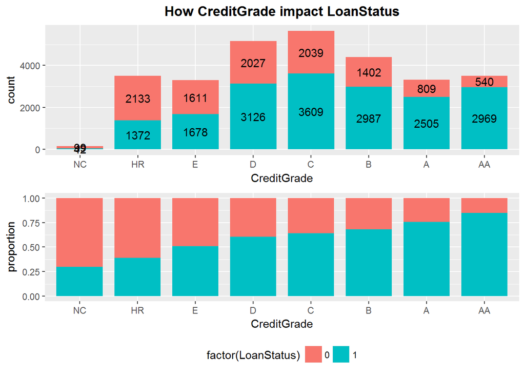

```r
# CreditGrade对LoanStatus的影响
gcg <- ggplot(loandata[!is.na(loandata$CreditGrade),], mapping = aes(
  x = CreditGrade,
  y = ..count..,
  fill = factor(LoanStatus)
)) + mythem1
gcg1 <- gcg + geom_bar(stat = "count",
                       position = "stack",
                       width = 0.8) +
  labs(title = "How CreditGrade impact LoanStatus") +
  geom_text(stat = "count",
            aes(label = ..count..),
            position = position_stack(vjust = 0.5))+
  theme(legend.position = "none")
gcg2 <- gcg + geom_bar(stat = "count",
                       position = "fill",
                       width = 0.8) + labs(y = "proportion")

grid.arrange(gcg1, gcg2, nrow = 2)
```

2009.07.01之前随着信用评级高的提高，违约概率大幅降低。

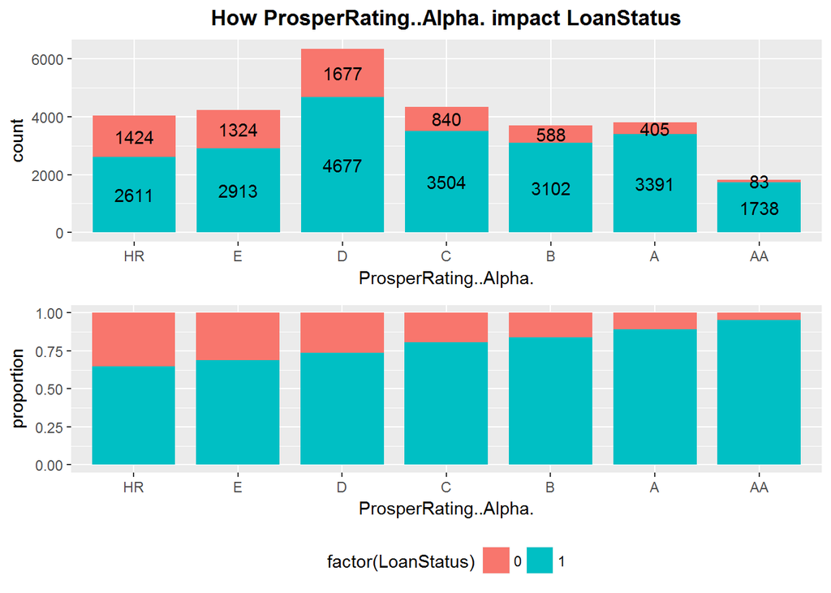

```r
# ProsperRating..Alpha.对LoanStatus的影响
gal <- ggplot(loandata[!is.na(loandata$ProsperRating..Alpha.),], mapping = aes(
  x = ProsperRating..Alpha.,
  y = ..count..,
  fill = factor(LoanStatus)
)) + mythem1
gal1 <- gal + geom_bar(stat = "count", position = "stack", width = 0.8) +
  labs(title = "How ProsperRating..Alpha. impact LoanStatus") +
  geom_text(stat = "count",aes(label = ..count..),
  position = position_stack(vjust = 0.5)) +
  theme(legend.position = "none")
gal2 <- gal + geom_bar(stat = "count", position = "fill",width = 0.8) +
        labs(y = "proportion")
grid.arrange(gal1, gal2, nrow = 2)
```

2009.07.01之后随着信用评级高的提高，违约概率也是大幅降低，且在相同等级下比2009.07.01之前违约比例也低，说明平台风控能力在逐步提升。

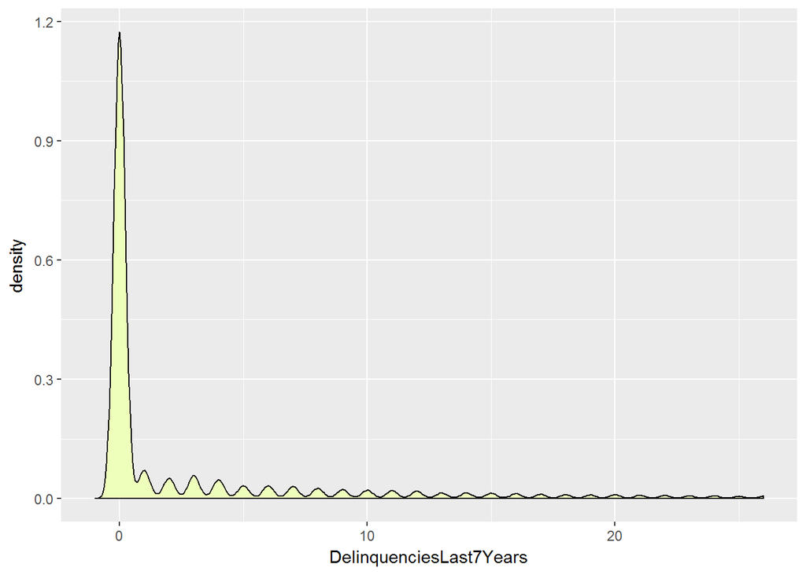

```r
# 借款人过去7年的违约次数
ggplot(aes(x = DelinquenciesLast7Years),data = loandata) +
  geom_density(aes(fill = I('#EEFFBB'))) +
  scale_x_continuous(limits = c(-1,quantile(loandata$DelinquenciesLast7Years,
                                            probs = 0.95, na.rm = TRUE)))
```

```r
summary(loandata$DelinquenciesLast7Years)
```

```
##    Min. 1st Qu.  Median    Mean 3rd Qu.    Max.    NA's
##   0.000   0.000   0.000   4.579   4.000  99.000     987
```

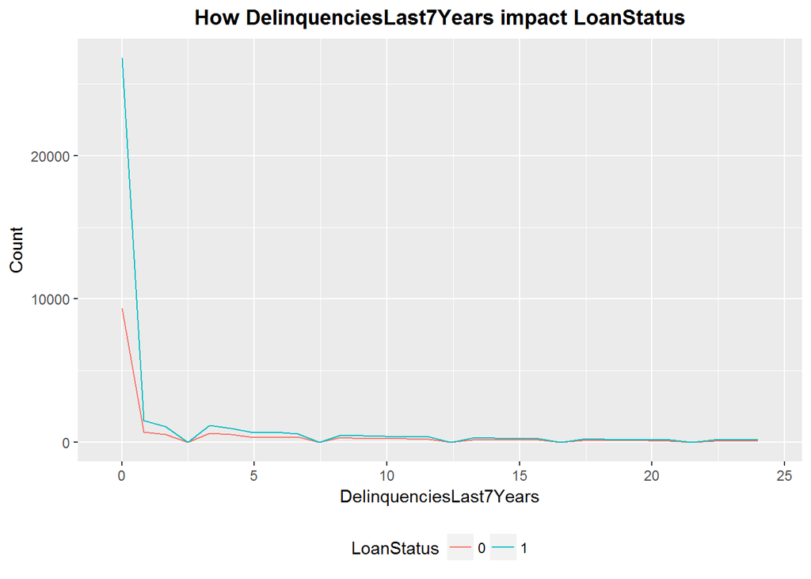

```r
ggplot(data = loandata[(!is.na(loandata$DelinquenciesLast7Years)) &
                         loandata$DelinquenciesLast7Years < 25,],
       aes(x = DelinquenciesLast7Years, color = LoanStatus)) +
       geom_line(aes(label = ..density..), stat = 'bin')  +
       labs(title = "How DelinquenciesLast7Years impact LoanStatus",
       x = "DelinquenciesLast7Years",
       y = "Count",
       fill = "LoanStatus") + mythem1
```

从上述折线图中看到,绝大部分人在过去7年内的违约次数都为0，这也说明了借款人的资质比较好。因为在过去的违约次数较少，一定程度上在将来说明这些客户违约的可能性也小一些。

```r
# 借款人工作状态持续时间
summary(loandata$EmploymentStatusDuration)
```

```
##    Min. 1st Qu.  Median    Mean 3rd Qu.    Max.    NA's
##    0.00   21.00   53.00   81.62  113.00  755.00    7611
```

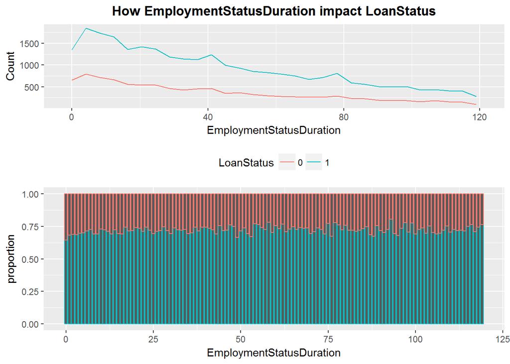

```r
time1 <- ggplot(data = loandata[(!is.na(loandata$EmploymentStatusDuration)) &
                         loandata$EmploymentStatusDuration < 120,],
       aes(x = EmploymentStatusDuration, color = LoanStatus)) +
       geom_line(aes(label = ..count..), stat = 'bin')  +
       labs(title = "How EmploymentStatusDuration impact LoanStatus",
       x = "EmploymentStatusDuration",
       y = "Count",
       fill = "LoanStatus") + mythem1
time2 <- ggplot(data = loandata[(!is.na(loandata$EmploymentStatusDuration)) &
                         loandata$EmploymentStatusDuration < 120,],
       aes(x = EmploymentStatusDuration, color = LoanStatus)) +
  geom_bar(stat = "count", position = "fill",width = 0.8) +
  labs(y = "proportion")+
  theme(legend.position = "none")

grid.arrange(time1, time2, nrow = 2)
```

受雇佣状态持续时间(EmploymentStatusDuration)可衡量一个人工作生活的稳定情况，从上图可看出，随着受雇佣状态持续时间长，贷款人数也递减。但受雇佣状态持续时常与违约的概率几乎没关系，说明平台以持续工作5年以内的年轻人为主要客户，这为今后的客户推广指明了方向。

## 用户总结

### 资金借贷情况分析

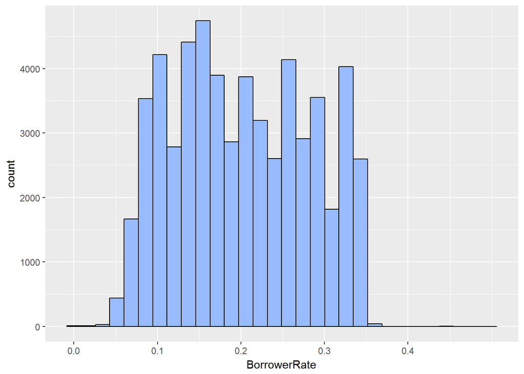

```r
# 借贷利率分布和期限分布

qplot(BorrowerRate,data = loandata,color = I('black'),
            fill = I('#99BBFF')) +
   scale_x_continuous(breaks = seq(0,0.4,0.1))
```

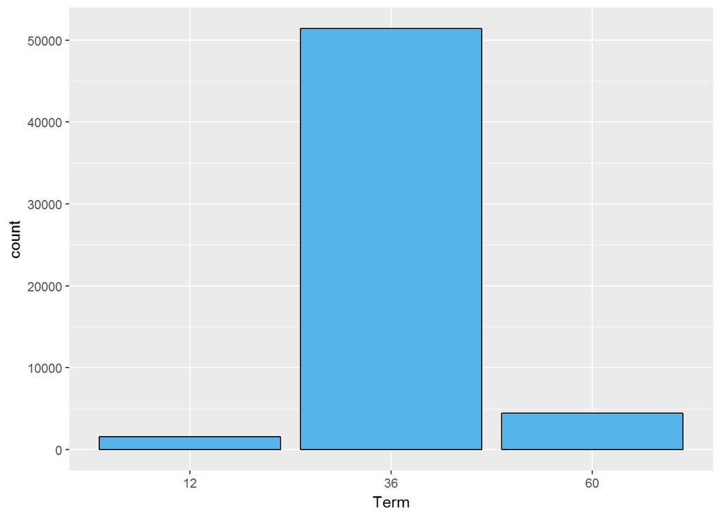

```r
loandata$Term <- factor(loandata$Term)
ggplot(aes(Term),data = loandata) +
  geom_bar(color=I('black'),fill = I('#56B4E9'))
```

图中可以看到，借款利率大体呈现正态分布，而借款期限来看，36期的借款明显更受欢迎，占比达到80%以上。

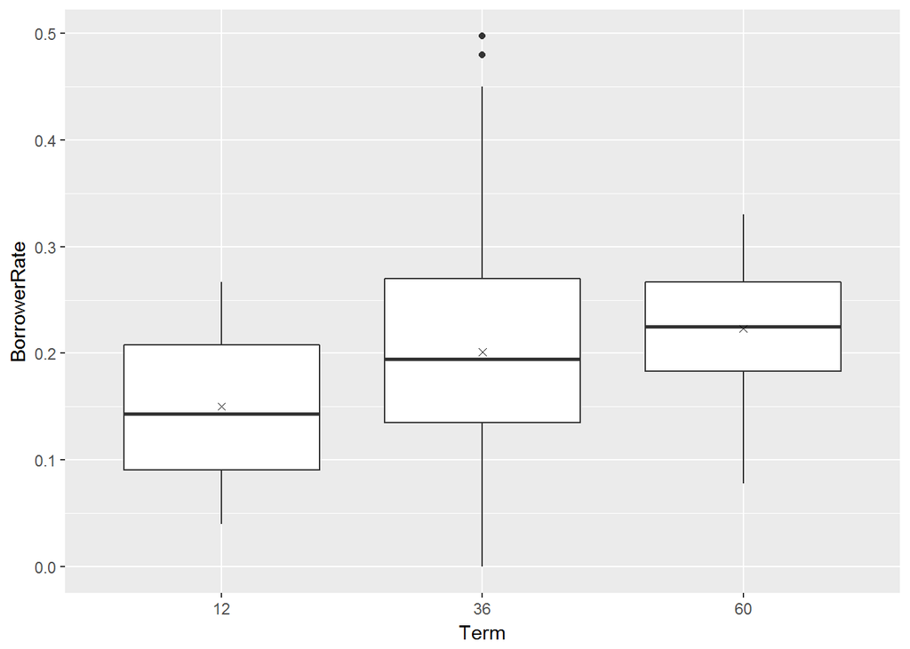

```r
# 借贷利率与期限的关系

ggplot(aes(x = Term, y = BorrowerRate),data = loandata) +
  geom_boxplot() +
   stat_summary(fun.y = mean,geom = 'point',shape = 4)
```

从箱线图中可以看到，中位数与均值很接近，并且异常值很少。可以看出，贷款利率与资金借贷期限有一定的正相关性，即借期越长，贷款利率越高。

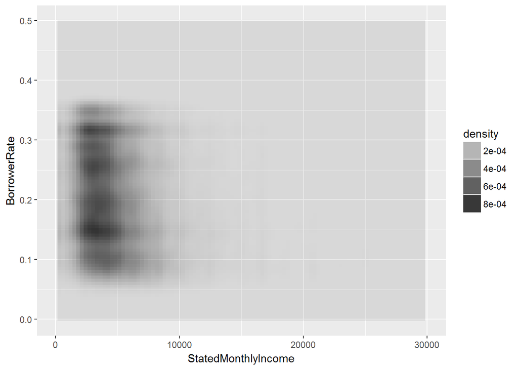

```r
# 贷款利率和客户月收入

ggplot(aes(StatedMonthlyIncome,BorrowerRate),data = subset(loandata, !is.na(StatedMonthlyIncome))) +
 stat_density2d(aes(alpha = ..density..), geom = 'tile', contour = FALSE) +
  scale_x_continuous(limits = c(0,30000))
```

从核密度图看出，月收入集中在$10000以下，但是没有看到资金价格与月收入有什么明显的关系。